# Blog post: Smart quotes, em dashes, and en dashes

Steve Simon

2020-03-02

If you work with text data a lot, you will encounter some characters that are sort of close to what you need, but sort of not. These include the smart quotes, em dashes, and en dashes.

### Smart quotes

Programmers use a set of standard quotation marks in their work. These are called straight quotes by some and dumb quotes by others.

The straight double quote (") is one of the standard codes that works pretty much the same on any computer system.

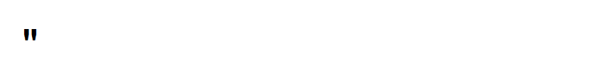

On early computer systems, this was all you had. You might have a backwards slanting single quote (`), often called a backtick.

This was a step backwards from Guttenberg’s printing press. Actually, the regression occurred when the typewriter was invented. The limited number of keys that you could fit into a typewriter

[figure not shown]

prevented the use of a greater variety of quote marks.

Now you probably already know this but if you want to assign a double quote to a variable, you surround it with single quotes,

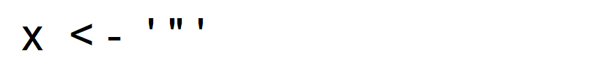

or precede the double quotes with a backslash

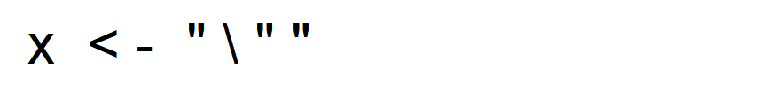

Use the charToRaw function to see the underlying code for the double quote mark

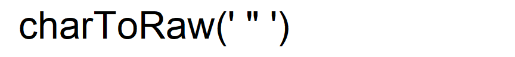

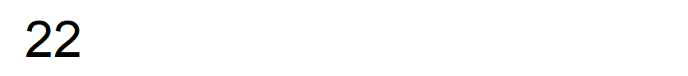

and for the single quote mark

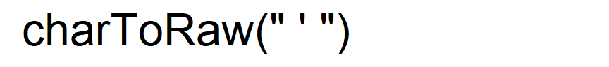

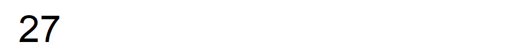

and for the backtick

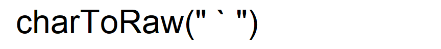

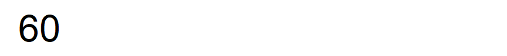

These values are hexadecimal, so 27 in hexadecimal is 2*16+7=39 in decimal.

If you know the hexadecimal code, you can convert it to the character equivalent using the prefix.

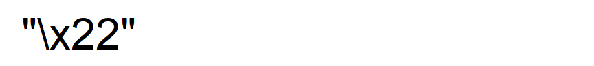

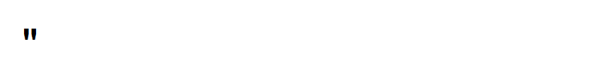

When personal computers started to expand beyond the limited character set, that allowed you to use the left double quote,

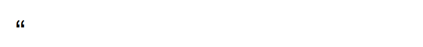

the right double quote,

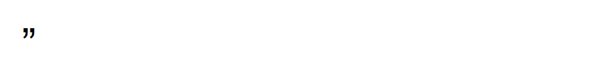

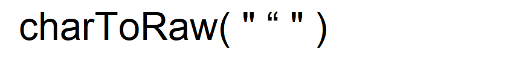

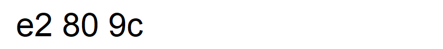

Surprise! When you open the world up to different typographic characters, you have to include characters with accents,

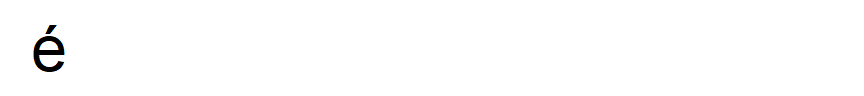

cedillas,

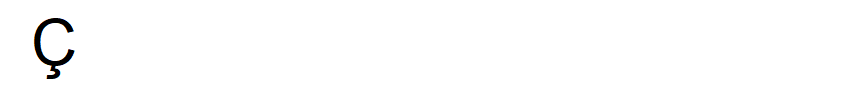

and tildes.

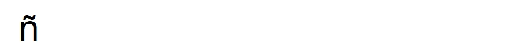

You have to have room for the sharp S in German,

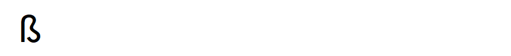

the thorn in Icelandic,

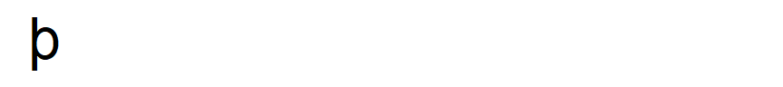

and a whole host of new characters in Greek,

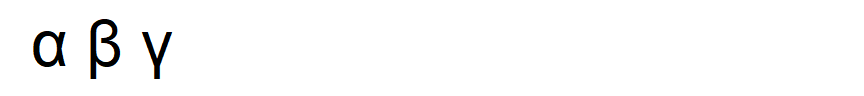

Arabic,

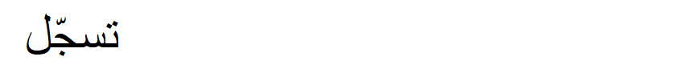

and Chinese.

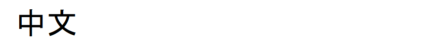

When you add various emojis

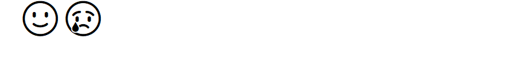

the list becomes quite long. The system that encodes all of these values is Unicode.